# S1.5: il simulatore del livello cellulare funziona tutto insieme, con i sei preset dei tessuti, e sa riconoscere la propria scala?

geo_spatialtrans, report di step (protocollo v2)

Published

October 21, 2026

# In breve

## In breve: il simulatore delle cellule funziona tutto insieme, nei sei tessuti, e sa trovare da solo la scala dell’immagine?

**A cosa serviva.** Negli step precedenti abbiamo costruito uno per uno i pezzi del simulatore: le regioni del tessuto, i centri delle cellule, i territori di Voronoi attorno ai centri, i nuclei. Qui li abbiamo riuniti in una sola funzione, con i controlli che fermano una simulazione sbagliata e con le impostazioni dei sei tessuti del pannello, prese dai riferimenti attuali. Poi abbiamo fatto girare il simulatore completo sulle stesse 30 aree di tessuto vero degli step precedenti (5 per tessuto, 10 ripetizioni ciascuna) e l’abbiamo confrontato con le cellule vere. Infine abbiamo provato se il programma sa ricavare da solo la scala dell’immagine, cioè quanti micron vale un pixel.

**Cosa abbiamo trovato.**

1. **Una delle prove scritte in anticipo non si può superare: il controllo sulla taglia delle cellule non si accorge di una scala sbagliata.**
   - Avevamo scritto che, con una scala sbagliata di 10 volte, il controllo sulla taglia mediana delle cellule sarebbe scattato. Non succede, e non può succedere. Le densità dei tessuti sono in cellule per millimetro quadrato: una scala sbagliata cambia quante cellule si piazzano, non quanto sono grandi (raggio mediano 4,86 µm sia con la scala giusta sia con quella 10 volte più grande).
   - Il controllo scatta invece quando la densità è scritta nell’unità sbagliata, ed è questo che sa fare.
   - Per questo le due prove della batteria di test che lo chiedevano falliscono; le altre 81 passano.
   - Conseguenza: la scala deve venire dall’utente o dai metadati dello Space Ranger, che la danno esatta in tutti e 5 i dataset.
2. **Il simulatore completo è corretto e i suoi controlli vedono gli errori.**
   - 600 simulazioni senza errori; rifatte con lo stesso seme danno file identici.
   - Tutti i 630 guasti inseriti apposta (territori sovrapposti, buchi, nuclei fuori posto, aree mancanti) sono stati rilevati.
   - Il revisore del codice ha trovato buchi nei controlli. Per esempio, un buco nella copertura del tessuto creato dal programma stesso passava inosservato, e due cellule con le righe della tabella scambiate non venivano viste. Nessuno di questi buchi era attivo nelle 600 simulazioni.
   - Li abbiamo corretti. Ora sono rilevati tutti i guasti costruiti dal revisore, e 18 delle sue 19 modifiche sabotate al codice; la diciannovesima spegne un controllo che gli altri due già coprono. Ricontrollate con i controlli corretti, le 600 simulazioni danno gli stessi file e gli stessi esiti.
   - Su una sezione grande di linfonodo (16 mm², 450 000 cellule) il simulatore impiega 5 minuti e 10 secondi e 8,5 GB di memoria, appena sopra i limiti che avevamo fissato (5 minuti, 8 GB). Negli altri tessuti va da 18 secondi a poco più di 2 minuti.
3. **La taglia dei nuclei torna in tutti e sei i tessuti; lo spazio attorno al nucleo torna in quattro.**
   - L’area mediana del nucleo simulato sta dentro la variabilità fra le aree vere in tutti e sei i tessuti: per esempio 13 µm² nell’intestino di topo, 31 nel tumore del colon, 64 nel cervello di topo.
   - Per arrivarci abbiamo dovuto adattare il modello della taglia dei nuclei. Era stato stimato sui nuclei trovati dai programmi di segmentazione, mentre il simulatore usa le densità contate a mano, che sono diverse (più alte nell’intestino, nel tumore e nel cervello, più basse nello stroma e nel cuore). Fra le due regole provate, scelte con un criterio scritto prima, ha vinto quella che conserva il legame misurato fra nucleo e territorio: sei tessuti giusti su sei, contro quattro.
   - La frazione della cellula occupata dal nucleo è giusta in quattro tessuti. È troppo bassa nell’intestino di topo (0,18 contro 0,22-0,23 nelle aree vere), come ci aspettavamo, e appena sotto nel tumore del colon (0,306 contro almeno 0,309). Nel tumore del colon, con i territori delle cellule vere, torna (0,32).
   - Nel tumore del colon il 3,6 % delle cellule è quasi senza citoplasma, contro al massimo il 2,9 % nelle aree vere. È la coda già nota del modello della taglia con un solo tipo di cellula.
4. **Nei tessuti densi i nuclei simulati si toccano troppo e i territori sono troppo uniformi; la causa è la disposizione dei centri delle cellule.**
   - Nel tumore del colon si toccano 62 nuclei su 100, contro 22-57 nei conteggi fatti a mano; nel linfonodo 83 contro 35-75. Nell’intestino di topo e nel cervello di topo il valore torna; nello stroma del tumore e nel cuore è al limite.
   - Con i centri delle cellule vere al posto di quelli simulati, gli stessi nuclei tornano dentro i conteggi a mano in cinque tessuti e restano al limite nel linfonodo. L’eccesso viene quindi da come piazziamo i centri: in modo uniforme in tutta la regione, mentre nei tessuti veri le cellule si raggruppano.
   - Per la stessa causa i territori simulati sono più uniformi di quelli veri in cinque tessuti su sei: la variabilità delle loro aree è più bassa di un quarto fino a quasi la metà. Nel cuore torna, ma il risultato è fragile: cambia se si escludono poche cellule che hanno ricevuto pezzi staccati dalle vicine.
   - L’uniformità era nota da quando abbiamo studiato la disposizione dei centri e i territori; ora sappiamo che pesa anche sui contatti fra nuclei.
5. **Il programma non sa ricavare la scala dall’immagine; lo abbiamo tolto dall’uso normale.**
   - Sulle 30 immagini vere riportate a scale note (1, 2, 5 e 10 micron per pixel), a 1 micron per pixel ha trovato la scala giusta solo nel linfonodo. Negli altri tessuti ha rifiutato di rispondere oppure ha sbagliato, nel cuore di 4 volte.
   - In 23 casi su 120 ha dato un numero sbagliato senza avvisare. Un controllo aggiunto dopo li riduce a 8, non a zero.
   - Ora il simulatore rifiuta la stima dall’immagine, a meno che la si chieda in modo esplicito.

**Cosa devi decidere.**

1. **Accettiamo che la prova «con la scala sbagliata scatta il controllo sulla taglia» fosse scritta male, e che la scala debba venire solo dall’utente o dai metadati? Consiglio di sì.**
   - La prova chiedeva una cosa impossibile con densità in unità assolute: il calcolo sopra lo mostra, e due prove aggiunte lo confermano (la taglia non cambia con la scala; il controllo scatta con la densità nell’unità sbagliata).
   - Tutte le altre prove della batteria passano, anche dopo le correzioni della revisione.
   - È la stessa situazione delle due volte in cui hai già accettato un controllo scritto male (la soglia di precisione sulle aree dei nuclei, il centro dei nuclei nel tessuto valido).
   - Alternativa: cercare un controllo della scala che guardi l’immagine. Il solo metodo che abbiamo è la stima dall’immagine, che questo step ha bocciato: servirebbe uno step dedicato, senza un candidato pronto. Intanto lo step resterebbe aperto.

**Comunque:** - quando lavoreremo sulla disposizione dei centri delle cellule, li faremo raggruppare come nei tessuti veri e rimisureremo contatti, variabilità dei territori e spazio attorno al nucleo sulle stesse 30 aree, compreso il caso fragile del cuore; - quando porteremo i tipi cellulari nel simulatore, correggeremo la coda delle cellule senza citoplasma nel tumore del colon; - prima di simulare la griglia di Visium HD, renderemo il simulatore più veloce e meno avido di memoria nel linfonodo: oggi il disegno dei nuclei da solo prende più di 2 minuti su 5; - il documento di progetto è aggiornato: il controllo sulla taglia non garantisce la scala, e la stima dall’immagine non è raccomandata. (Frase corretta dopo la tua lettura: il documento era già aggiornato in bozza.)

Appena decidi questo punto, lo step è chiuso.

# Decisioni e verifiche di Luca

- «S1.5 = orchestratore, controlli, preset e scala; i tipi dopo (Recommended)» (scelta del perimetro in chat, 2026-10-21)
- «Sono domande a cui abbiamo già risposto nella sessione precedente, non devi richiedermelo perché la risposta si deve basare sui dati e non sulle mie preferenze» (in chat, 2026-10-21, sulle tre scelte del modello; estratto, ortografia corretta)
- «Approvo così» (ok sulle previsioni, in chat, 2026-10-21)
- Decisione del riassunto, alla domanda «Accettiamo che la prova «con la scala sbagliata scatta il controllo sulla taglia» fosse scritta male, e che la scala debba venire solo dall’utente o dai metadati?»: «si» (trascritto dalla chat, 2026-10-21) → Il caso limite «scala sbagliata di 10 volte, scatta C8» fallito in S1.5 e’ un errore della pre-registrazione: la scala viene dall’utente o dai metadati (DEC-011).
- Proposta di aggiungere alla skill di sessione la regola «le scelte che i dati possono decidere si decidono con una regola scritta prima del calcolo, e non si chiedono a Luca»: «ok» (trascritto dalla chat, 2026-10-21).
- Luca ha letto il riassunto e deciso il punto senza sollevare dubbi nuovi: **step chiuso**.

# Dubbi rinviati

[output not shown]

# Cancelli

Pre-registrazione: commit `6042a89` (cancelli), ok di Luca sulle previsioni il 2026-10-21 («Approvo così») e scelte decise dai dati, commit `710f5df`; codice e note di sviluppo D-1…D-9 prima della corsa ufficiale, commit `dab8b3a`; script di analisi prima dei risultati, `e85a1d8`; risultati `fafb3d0`; correzioni dopo la revisione `ab03c27`.

| id | controllo | esito |
| --- | --- | --- |
| G-1 | batteria di S1.5 (`test_S1.5.R`) | RESULT 81/83 PASS (mutante none) |
| G-1 | regressione S1.1, S1.2, S1.3, S1.4; S1.4d; OKF | 4 regressioni identiche; RESULT 36/36 PASS (mutante none) ; RESULT 8/8 PASS |
| G-1 | esito del cancello | GATE G-1 FAIL |
| G-2 | mutanti M1-M9 | mutanti rilevati 9/9 - GATE G-2 PASS |
| G-3 | unita’ del pannello senza ERROR (C2, C3, C5, C9) | 600/600 |
| G-3 | rerun identico e catena manuale (6 unita’) | rerun 6/6, catena 6/6 |
| G-3 | ricontrollo delle 600 unita’ dopo le correzioni | senza ERROR 600/600, md5 uguale 600/600 |
| G-4 | guasti costruiti (630) | 630/630 rilevati dal controllo atteso |
| G-4 | nulli di S1.3 (1 800) | 1800/1800 senza ERROR |
| G-5 | ricalcolo indipendente | 274/277 concordi entro 1e-9 (vedi «Revisione avversariale») |

- **G-1 fallito come scritto**: falliscono solo E10 ed E10b, il caso limite del design «con `pixel_size_um` sbagliato di 10 volte C8 scatta». Con la densita’ del catalogo in cellule/mm² una scala sbagliata cambia il numero di cellule, non il loro raggio: E10d (aggiunto) misura un raggio mediano di 4.862 µm a 1 µm/px e 4.857 µm a 10 µm/px; E10c (aggiunto) mostra che C8 scatta con la densita’ in unita’ sbagliate. Nota D-3; **errore di pre-registrazione, decisione di Luca nel riassunto**. Tutte le altre asserzioni passano, prima e dopo le correzioni della revisione.
- G-1 e G-2 sono stati rieseguiti al commit `ab03c27` (log in `/mnt/micron/geo_spatialtrans/S1.5/tests/final2`); il primo giro ufficiale, al commit `fafb3d0`, dava 67/69 con gli stessi due FAIL.
- md5 dei 126 file letti (maschere, immagini, riferimenti): 125/126 identici prima e dopo tutte le corse. Il solo diverso e’ docs/BIO_REFERENCES.md, perche’ a fine step vi sono state aggiunte le righe B-155…B-160; la versione usata dalle corse (commit `ab03c27`) ha md5 c6591d168ea7e080a19953077d7f6901, uguale a quello di prima.

# Previsioni

Unita’ indipendente: ROI (5 per tessuto) per P-1…P-4, P-6, P-7; seme per P-5; ripetizione per P-8. Stima ± 2 errori standard. Braccio vincente della regola della scelta 2: preserve_area (P-1 confermata in 6 tessuti; l’altro braccio in 4).

| id | tessuto | quantita’ | intervallo di rilevanza (fonte) | stima [± 2 ES] | esito |
| --- | --- | --- | --- | --- | --- |
| P-1 | intestino | area mediana del nucleo (um2), celle interne | 12.59-13.79 (variabilita’ fra ROI reali) | 13.2015 [13.1654, 13.2376] | confermata |
| P-2 | intestino | rapporto mediano nucleo/territorio, celle interne | 0.2165-0.2309 (variabilita’ fra ROI reali) | 0.1834 [0.1827, 0.1841] | smentita |
| P-3 | intestino | frazione di nuclei troncati dal tetto | 0-0.05 (criterio di Luca (ROADMAP §4, S1.4)) | 0.0156 [0.0152, 0.0161] | confermata |
| P-4 | intestino | frazione di cellule quasi senza citoplasma, celle interne | 0-0.002017 (variabilita’ fra ROI reali (massimo)) | 0.0000 [0.0000, 0.0000] | confermata |
| P-6 | intestino | CV dell’area dei territori, simulato / reale - 1 | -0.1-0.1 (soglia S1.3 B-2 (Luca, 2026-10-08)) | -0.4156 [-0.4514, -0.3798] | smentita |
| P-7 | intestino | eccentricita’ mediana del territorio, simulato - reale | -0.05-0.05 (soglia S1.3 B-4 (Luca, 2026-10-08)) | -0.0142 [-0.0201, -0.0084] | confermata |
| P-1 | tumore del colon | area mediana del nucleo (um2), celle interne | 27.94-32.44 (variabilita’ fra ROI reali) | 31.0902 [30.9840, 31.1964] | confermata |
| P-2 | tumore del colon | rapporto mediano nucleo/territorio, celle interne | 0.3094-0.4334 (variabilita’ fra ROI reali) | 0.3060 [0.3051, 0.3069] | smentita |
| P-3 | tumore del colon | frazione di nuclei troncati dal tetto | 0-0.05 (criterio di Luca (ROADMAP §4, S1.4)) | 0.0305 [0.0295, 0.0314] | confermata |
| P-4 | tumore del colon | frazione di cellule quasi senza citoplasma, celle interne | 0-0.02873 (variabilita’ fra ROI reali (massimo)) | 0.0358 [0.0348, 0.0368] | smentita |
| P-6 | tumore del colon | CV dell’area dei territori, simulato / reale - 1 | -0.1-0.1 (soglia S1.3 B-2 (Luca, 2026-10-08)) | -0.4150 [-0.5287, -0.3013] | smentita |
| P-7 | tumore del colon | eccentricita’ mediana del territorio, simulato - reale | -0.05-0.05 (soglia S1.3 B-4 (Luca, 2026-10-08)) | 0.0158 [0.0069, 0.0247] | confermata |
| P-1 | stroma | area mediana del nucleo (um2), celle interne | 27.79-33.79 (variabilita’ fra ROI reali) | 33.5834 [33.5130, 33.6538] | confermata |
| P-2 | stroma | rapporto mediano nucleo/territorio, celle interne | 0.1166-0.3371 (variabilita’ fra ROI reali) | 0.1175 [0.1170, 0.1179] | confermata |
| P-3 | stroma | frazione di nuclei troncati dal tetto | 0-0.05 (criterio di Luca (ROADMAP §4, S1.4)) | 0.0026 [0.0024, 0.0028] | confermata |
| P-4 | stroma | frazione di cellule quasi senza citoplasma, celle interne | 0-0.02084 (variabilita’ fra ROI reali (massimo)) | 0.0000 [0.0000, 0.0000] | confermata |
| P-6 | stroma | CV dell’area dei territori, simulato / reale - 1 | -0.1-0.1 (soglia S1.3 B-2 (Luca, 2026-10-08)) | -0.4348 [-0.5383, -0.3312] | smentita |
| P-7 | stroma | eccentricita’ mediana del territorio, simulato - reale | -0.05-0.05 (soglia S1.3 B-4 (Luca, 2026-10-08)) | 0.0213 [0.0102, 0.0325] | confermata |
| P-1 | linfonodo | area mediana del nucleo (um2), celle interne | 15.67-16.64 (variabilita’ fra ROI reali) | 16.3154 [16.3076, 16.3232] | confermata |
| P-2 | linfonodo | rapporto mediano nucleo/territorio, celle interne | 0.4491-0.5013 (variabilita’ fra ROI reali) | 0.4677 [0.4675, 0.4678] | confermata |
| P-3 | linfonodo | frazione di nuclei troncati dal tetto | 0-0.05 (criterio di Luca (ROADMAP §4, S1.4)) | 0.0145 [0.0143, 0.0147] | confermata |
| P-4 | linfonodo | frazione di cellule quasi senza citoplasma, celle interne | 0-0.002431 (variabilita’ fra ROI reali (massimo)) | 0.0000 [0.0000, 0.0000] | confermata |
| P-6 | linfonodo | CV dell’area dei territori, simulato / reale - 1 | -0.1-0.1 (soglia S1.3 B-2 (Luca, 2026-10-08)) | -0.4243 [-0.5517, -0.2969] | smentita |
| P-7 | linfonodo | eccentricita’ mediana del territorio, simulato - reale | -0.05-0.05 (soglia S1.3 B-4 (Luca, 2026-10-08)) | 0.0121 [-0.0005, 0.0248] | confermata |
| P-1 | cervello | area mediana del nucleo (um2), celle interne | 56.88-119.2 (variabilita’ fra ROI reali) | 64.1252 [62.9660, 65.2843] | confermata |
| P-2 | cervello | rapporto mediano nucleo/territorio, celle interne | 0.08208-0.1108 (variabilita’ fra ROI reali) | 0.0876 [0.0862, 0.0889] | confermata |
| P-3 | cervello | frazione di nuclei troncati dal tetto | 0-0.05 (criterio di Luca (ROADMAP §4, S1.4)) | 0.0235 [0.0212, 0.0257] | confermata |
| P-4 | cervello | frazione di cellule quasi senza citoplasma, celle interne | 0-0 (variabilita’ fra ROI reali (massimo)) | 0.0000 [0.0000, 0.0000] | confermata |
| P-6 | cervello | CV dell’area dei territori, simulato / reale - 1 | -0.1-0.1 (soglia S1.3 B-2 (Luca, 2026-10-08)) | -0.2600 [-0.3518, -0.1682] | smentita |
| P-7 | cervello | eccentricita’ mediana del territorio, simulato - reale | -0.05-0.05 (soglia S1.3 B-4 (Luca, 2026-10-08)) | -0.0014 [-0.0120, 0.0092] | confermata |
| P-1 | cuore | area mediana del nucleo (um2), celle interne | 17.54-31.71 (variabilita’ fra ROI reali) | 21.8690 [21.7607, 21.9773] | confermata |
| P-2 | cuore | rapporto mediano nucleo/territorio, celle interne | 0.02354-0.03659 (variabilita’ fra ROI reali) | 0.0259 [0.0253, 0.0264] | confermata |
| P-3 | cuore | frazione di nuclei troncati dal tetto | 0-0.05 (criterio di Luca (ROADMAP §4, S1.4)) | 0.0119 [0.0104, 0.0135] | confermata |
| P-4 | cuore | frazione di cellule quasi senza citoplasma, celle interne | 0-0 (variabilita’ fra ROI reali (massimo)) | 0.0000 [0.0000, 0.0000] | confermata |
| P-6 | cuore | CV dell’area dei territori, simulato / reale - 1 | -0.1-0.1 (soglia S1.3 B-2 (Luca, 2026-10-08)) | -0.0556 [-0.1000, -0.0112] | confermata |
| P-7 | cuore | eccentricita’ mediana del territorio, simulato - reale | -0.05-0.05 (soglia S1.3 B-4 (Luca, 2026-10-08)) | -0.0120 [-0.0192, -0.0048] | confermata |
| P-5 | intestino | frazione di nuclei a contatto, finestre di R2c a peso uguale | 0.366-0.65 (B-127 (manuale, due stadi)) | 0.4692 [0.4434, 0.4951] | confermata |
| P-5 | tumore del colon | frazione di nuclei a contatto, finestre di R2c a peso uguale | 0.217-0.567 (B-128 (manuale, due stadi)) | 0.6195 [0.5939, 0.6452] | smentita |
| P-5 | stroma | frazione di nuclei a contatto, finestre di R2c a peso uguale | 0.083-0.283 (B-129 (manuale, due stadi)) | 0.2993 [0.2683, 0.3302] | indeterminata |
| P-5 | linfonodo | frazione di nuclei a contatto, finestre di R2c a peso uguale | 0.35-0.75 (B-130 (manuale, due stadi)) | 0.8323 [0.8157, 0.8489] | smentita |
| P-5 | cervello | frazione di nuclei a contatto, finestre di R2c a peso uguale | 0-0.217 (B-131 (manuale, due stadi)) | 0.1077 [0.0833, 0.1320] | confermata |
| P-5 | cuore | frazione di nuclei a contatto, finestre di R2c a peso uguale | 0-0.07 (B-132 (manuale, due stadi)) | 0.0838 [0.0661, 0.1015] | indeterminata |
| P-8 | cervello | tempo di place_cells (s), 4000 x 4000 px | 0-300 (design v1.1, casi limite) | 20.0447 [19.6245, 20.4648] | confermata |
| P-8 | cervello | memoria di picco del processo (GB decimali; 4.81 GiB) | 0-8 (design v1.1, casi limite) | 5.1675 [5.1675, 5.1675] | confermata |
| P-8 | cuore | tempo di place_cells (s), 4000 x 4000 px | 0-300 (design v1.1, casi limite) | 18.0560 [17.8199, 18.2921] | confermata |
| P-8 | cuore | memoria di picco del processo (GB decimali; 4.71 GiB) | 0-8 (design v1.1, casi limite) | 5.0608 [5.0608, 5.0608] | confermata |
| P-8 | intestino | tempo di place_cells (s), 4000 x 4000 px | 0-300 (design v1.1, casi limite) | 128.7603 [127.2041, 130.3165] | confermata |
| P-8 | intestino | memoria di picco del processo (GB decimali; 6.28 GiB) | 0-8 (design v1.1, casi limite) | 6.7462 [6.7462, 6.7462] | confermata |
| P-8 | linfonodo | tempo di place_cells (s), 4000 x 4000 px | 0-300 (design v1.1, casi limite) | 310.1323 [306.4702, 313.7945] | smentita |
| P-8 | linfonodo | memoria di picco del processo (GB decimali; 7.91 GiB) | 0-8 (design v1.1, casi limite) | 8.4967 [8.4967, 8.4967] | smentita |
| P-8 | stroma | tempo di place_cells (s), 4000 x 4000 px | 0-300 (design v1.1, casi limite) | 40.2870 [40.0196, 40.5544] | confermata |
| P-8 | stroma | memoria di picco del processo (GB decimali; 5.07 GiB) | 0-8 (design v1.1, casi limite) | 5.4447 [5.4447, 5.4447] | confermata |
| P-8 | tumore del colon | tempo di place_cells (s), 4000 x 4000 px | 0-300 (design v1.1, casi limite) | 104.7567 [103.8582, 105.6551] | confermata |
| P-8 | tumore del colon | memoria di picco del processo (GB decimali; 5.91 GiB) | 0-8 (design v1.1, casi limite) | 6.3429 [6.3429, 6.3429] | confermata |

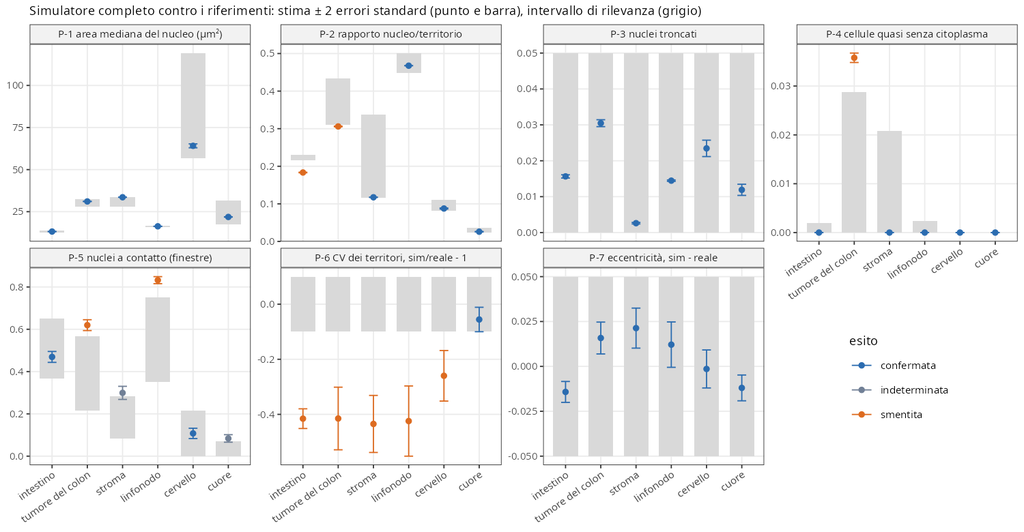

Previsioni P-1…P-7 per tessuto: stima ± 2 errori standard (punti) e intervallo di rilevanza (banda).

**Cosa guardare**: le aree dei nuclei (P-1) cadono tutte nelle bande; il CV dei territori (P-6) e’ sotto la banda in cinque tessuti, i contatti (P-5) sopra nel tumore del colon e nel linfonodo.

Spiegazione degli esiti smentiti e indeterminati:

- **P-2 intestino** (smentita, attesa): territori piu’ uniformi del reale, effetto della semina omogenea (pre-registrato). **P-2 tumore del colon** (smentita, non attesa, appena sotto il limite): con i territori reali lo stesso preset da’ 0.321, dentro (PH-2): stessa causa.
- **P-4 tumore del colon**: la coda del modello di taglia a un tipo (Nel tumore del colon nessun limite all’area del nucleo; la coda del modello di taglia si corregge con i tipi cellulari (DEC-005)); con i generatori reali 6.0 % (PH-3).
- **P-5 tumore del colon e linfonodo** (smentite), **stroma e cuore** (indeterminate): con i generatori reali i contatti tornano nell’intervallo manuale in cinque tessuti (PH-1, sotto). L’eccesso viene dalla semina omogenea.
- **P-6 in cinque tessuti** (smentita, attesa): gia’ misurata in S1.3 e R3. Nel cuore confermata con 2e-5 di margine; fragile (rilievo F-1).
- **P-8 linfonodo** (smentita): 310 s e 8.50 GB; il disegno dei nuclei prende circa 133 s (BL-144).

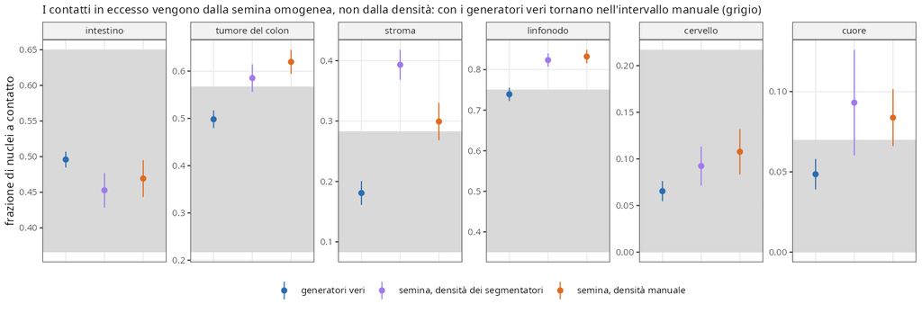

## Analisi dopo il risultato

- **D-11 Stima della scala dopo CP-1** (smentita come scritta). Correzione: controllo di coerenza nella stima dall’immagine (il raggio dei nuclei visto dal laplaciano, sqrt(2) · σ* · scala, deve stare entro un fattore 2 dal raggio atteso dal catalogo, altrimenti rifiuto; argomento `size_check`, test S9). Rieseguita come post hoc CP-1b sulle stesse 240 immagini: i numeri sbagliati restituiti senza rifiuto scendono da 23 a 8 sull’ingresso della pipeline e da 31 a 17 sulla maschera intera, non a 0. Conseguenza pre-registrata applicata: la stima dall’immagine esce dall’uso raccomandato; `place_cells(pixel_size_um = "estimate")` si ferma con errore se non si passa `allow_estimate = TRUE` (test S8). Restano raccomandati la scala dell’utente e i metadati (`scalefactors_json`, 5/5 dataset esatti).
- **D-12 Unita’ della memoria.** Lo script di analisi convertiva i kB di `/usr/bin/time` in GiB; il testo pre-registrato dice GB. Il verdetto si da’ in GB decimali come scritto (linfonodo 8.50 GB, 7.91 GiB); la colonna riporta entrambe.
- **PH-1 Contatti, scomposizione** (`tools/S1.5_posthoc.R`, `results/S1.5/S1.5_posthoc_windows.csv`): stessi ROI, semi e preset, tre generatori: territori e generatori reali; semina RSA alla densita’ dei nuclei segmentati; semina RSA alla densita’ manuale (il pannello). Frazione a contatto, generatori reali / RSA alla densita’ dei segmentatori / pannello: intestino 0.496 / 0.453 / 0.469; tumore del colon 0.498 / 0.585 / 0.620; stroma 0.181 / 0.393 / 0.299; linfonodo 0.739 / 0.824 / 0.832; cervello 0.065 / 0.092 / 0.108; cuore 0.049 / 0.093 / 0.084 (media dei 10 semi). Con i generatori reali i contatti stanno dentro gli intervalli manuali in cinque tessuti; nel linfonodo 0.739 ± 0.016 e’ a cavallo del limite 0.75, nella fascia 0.69-0.74 gia’ vista in R3b con la maschera unica (BL-142). Con la semina RSA salgono rispetto ai generatori reali in cinque tessuti su sei, anche alla densita’ dei segmentatori; nell’intestino scendono (0.453 contro 0.496). L’eccesso di P-5 in tumore del colon e linfonodo viene dalla semina omogenea, non dalla densita’ manuale. (Testo corretto dopo la revisione, rilievi F-2 e F-3; i numeri non cambiano.)
- **PH-2 Rapporto nucleo/territorio**: con i territori reali e lo stesso preset il tumore del colon e’ a 0.321 (dentro 0.309–0.433); scende con la semina RSA. Stessa causa di P-6. Nota: nel braccio con i generatori reali si usano tutte le celle interne, i riferimenti reali le sole celle interne appaiate (insieme di valutazione di S1.4); il confronto fra bracci usa lo stesso insieme.
- **PH-3 Cellule senza citoplasma nel tumore del colon**: con i generatori reali 6.0 % (S1.4d: 5.8 %), con la semina simulata 3.6 %; resta la coda del modello a un tipo (Nel tumore del colon nessun limite all’area del nucleo; la coda del modello di taglia si corregge con i tipi cellulari (DEC-005)).

PH-1: frazione di nuclei a contatto, media dei 10 semi ± 2 errori standard

| tessuto | pannello (RSA, densita’ manuale) | generatori reali | RSA, densita’ dei segmentatori | manuale, basso | manuale, alto |
| --- | --- | --- | --- | --- | --- |
| intestino | 0.469 ± 0.026 | 0.496 ± 0.011 | 0.453 ± 0.024 | 0.366 | 0.650 |
| tumore del colon | 0.620 ± 0.026 | 0.498 ± 0.019 | 0.585 ± 0.029 | 0.217 | 0.567 |
| stroma | 0.299 ± 0.031 | 0.181 ± 0.020 | 0.393 ± 0.025 | 0.083 | 0.283 |
| linfonodo | 0.832 ± 0.017 | 0.739 ± 0.016 | 0.824 ± 0.016 | 0.350 | 0.750 |
| cervello | 0.108 ± 0.024 | 0.065 ± 0.011 | 0.092 ± 0.021 | 0.000 | 0.217 |
| cuore | 0.084 ± 0.018 | 0.049 ± 0.009 | 0.093 ± 0.033 | 0.000 | 0.070 |

# Controprova

CP-1: la stima della scala dall’immagine sulle 30 immagini H&E ricampionate a 1, 2, 5 e 10 µm/px (ingresso della pipeline, `prepare_image()`); la variante «full_mask» e’ descrittiva (nota D-7).

| scala vera (µm/px) | tessuto | ROI rifiutati | numeri fuori 0.8-1.2 | rapporto stimata/vera [± 2 ES] | esito |
| --- | --- | --- | --- | --- | --- |
| 1 | intestino | 0 | 3 | 1.286 [1.165, 1.407] | indeterminata |
| 1 | tumore del colon | 4 | 1 |  | rifiuto (>= 3 ROI su 5) |
| 1 | stroma | 4 | 1 |  | rifiuto (>= 3 ROI su 5) |
| 1 | linfonodo | 0 | 0 | 0.872 [0.829, 0.915] | confermata |
| 1 | cervello | 5 | 0 |  | rifiuto (>= 3 ROI su 5) |
| 1 | cuore | 1 | 4 | 3.983 [2.693, 5.273] | smentita |
| 2 | intestino | 5 | 0 |  | rifiuto (>= 3 ROI su 5) |
| 2 | tumore del colon | 4 | 1 |  | rifiuto (>= 3 ROI su 5) |
| 2 | stroma | 5 | 0 |  | rifiuto (>= 3 ROI su 5) |
| 2 | linfonodo | 5 | 0 |  | rifiuto (>= 3 ROI su 5) |
| 2 | cervello | 5 | 0 |  | rifiuto (>= 3 ROI su 5) |
| 2 | cuore | 1 | 4 | 2.778 [2.446, 3.111] | smentita |
| 5 | intestino | 5 | 0 |  | rifiuto (>= 3 ROI su 5) |
| 5 | tumore del colon | 3 | 2 |  | rifiuto (>= 3 ROI su 5) |
| 5 | stroma | 5 | 0 |  | rifiuto (>= 3 ROI su 5) |
| 5 | linfonodo | 5 | 0 |  | rifiuto (>= 3 ROI su 5) |
| 5 | cervello | 5 | 0 |  | rifiuto (>= 3 ROI su 5) |
| 5 | cuore | 3 | 2 |  | rifiuto (>= 3 ROI su 5) |
| 10 | intestino | 1 | 4 | 0.097 [0.085, 0.109] | smentita |
| 10 | tumore del colon | 4 | 1 |  | rifiuto (>= 3 ROI su 5) |
| 10 | stroma | 5 | 0 |  | rifiuto (>= 3 ROI su 5) |
| 10 | linfonodo | 5 | 0 |  | rifiuto (>= 3 ROI su 5) |
| 10 | cervello | 5 | 0 |  | rifiuto (>= 3 ROI su 5) |
| 10 | cuore | 5 | 0 |  | rifiuto (>= 3 ROI su 5) |

Numeri restituiti senza rifiuto e fuori da 0.8-1.2, per scala vera (30 ROI per cella)

|  | variante | controllo | 1 | 2 | 5 | 10 |
| --- | --- | --- | --- | --- | --- | --- |
| full_mask | full_mask | come scritto | 15 | 8 | 5 | 3 |
| pipeline | pipeline | come scritto | 9 | 5 | 4 | 5 |
| full_mask | full_mask | con il controllo di coerenza (post hoc) | 9 | 4 | 2 | 2 |
| pipeline | pipeline | con il controllo di coerenza (post hoc) | 4 | 1 | 2 | 1 |

**Esito**: smentita. A 1 µm/px il rapporto sta dentro l’intervallo solo nel linfonodo (meno di 3 tessuti su 6): come pre-registrato, la stima dall’immagine esce dall’uso raccomandato (nota D-11, `allow_estimate = TRUE`). Il metodo dai metadati da’ la scala esatta sui 5 dataset (test S1).

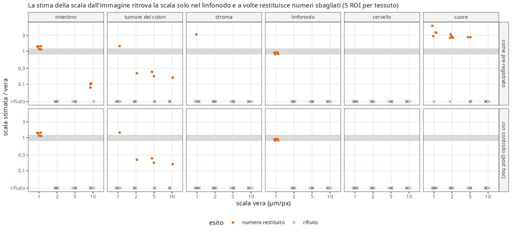

CP-1: rapporto fra scala stimata e vera per ROI, con e senza il controllo di coerenza.

# Revisione avversariale

Due revisori indipendenti al commit `fafb3d0`, in sola lettura sul repo, con codice proprio (uscite in `/mnt/micron/geo_spatialtrans/S1.5/review_recalc` e `review_code`; risposte strutturate in `results/S1.5/review/`)[^review].

- **Ricalcolo** (cancello G-5): 274 confronti su 277 coincidono entro 1e-9. Ricalcolati da zero: le 300 unita’ del braccio vincente (semi 2-10 rigenerati con `place_cells()`, md5 identico 270/270), 96/96 righe dei verdetti, la regola della scelta 2, i riferimenti reali dei 30 ROI, i nuclei in piu’ parti, i conteggi di G-3 e G-4, CP-1 (48/48), i post hoc. Le 3 voci non concordi non sono errori di calcolo (rilievi F-1, F-2, F-3, sotto). Limiti dichiarati dal revisore: area dei guasti ricalcolata con shapely su 21 dei 630 guasti; righe della semina alla densita’ dei segmentatori (PH-1, PH-2) non ricalcolabili dalle geometrie (territori non salvati); braccio «none» solo dalla tabella; «senza ERROR» delle 6 corse di prestazione solo dalla colonna `n_error`.
- **Codice**: nessun bug cambia un numero o un verdetto (84/84 verdetti P-1…P-7, 48/48 CP-1, 60/60 unita’ del seme 1, 54/54 valori dei preset). Mutanti dell’autore 9/9; mutanti del revisore rilevati 9 su 19; guasti indipendenti costruiti sui 30 layer del seme 1: rilevati tutti solo 4 tipi su 10 (scambio di due celle 0/30, nucleo dimezzato 0/30, `region_id` NA che ferma il validatore 30/30, uscita dalla regione senza segnale 4/30). 15 rilievi (FND-01…FND-15). Limiti dichiarati: ricalcoli per unita’ solo sul seme 1; eccentricita’ e contatti non ricalcolati dalle geometrie; codice Python dei contatti letto ma non rieseguito.

**D-13 Correzioni** (commit `ab03c27`, dopo la revisione):

[output not shown]

**D-14 Controprova delle correzioni** (stesso commit `ab03c27`):

- G-1: `test_S1.5.R` 81/83 (falliscono solo E10 ed E10b, D-3); `test_S1.4d.R` 36/36; S1.1, S1.2, S1.3, S1.4 identici agli esiti committati; OKF 8/8. G-2: 9/9.
- **Mutanti del revisore** rieseguiti con le stesse modifiche (`tools/S1.5_review_mutants.sh`; R15 adattato alla nuova riga di C6): rilevati 18 su 19 (prima 9). Non rilevato R18 (disgiunzione dei nuclei spenta): il controllo e’ implicato dagli altri due, perche’ se ogni nucleo sta nel suo territorio entro g · P e i territori si sovrappongono al piu’ τ, due nuclei si sovrappongono al piu’ τ + g · (P_i + P_j), cioe’ circa 1e-4 µm² per celle di 100 µm di perimetro: solo una sovrapposizione sotto questa soglia potrebbe sfuggire agli altri controlli.
- **Guasti indipendenti del revisore** rieseguiti con la stessa costruzione (`tools/S1.5_review_faults.R`): rilevati 282 su 282 costruiti (almeno un ERROR; i 30 layer di base hanno 0 ERROR), 0 arresti del validatore. Il controllo che scatta e’ spesso C9 invece di quello atteso dal revisore, perche’ i suoi guasti cambiano la geometria senza aggiornare `cell_df` e ora C9 lo vede per primo: la sensibilita’ di C2 e C3 a guasti con `cell_df` coerente e’ quella dei 630 guasti di G-4.
- **Le 600 unita’ del pannello ricontrollate** con il validatore corretto: 600/600 senza ERROR, md5 delle geometrie uguale al pannello 600/600, esiti dei controlli identici 600/600 (`results/S1.5/S1.5_G3_recheck.csv`). I verdetti non cambiano.
- md5 dei 126 file letti dalle corse: 125/126 identici prima e dopo; il solo diverso e’ `docs/BIO_REFERENCES.md`, perche’ a fine step vi sono state aggiunte le righe B-155…B-160 (6 righe aggiunte, 0 tolte); la versione usata dalle corse (commit `ab03c27`) ha lo stesso md5 di prima.
- G-4 rieseguito: guasti 630/630 rilevati dal controllo atteso (`S1.5_G4_faults_v2.csv`); nulli di S1.3 con i semi separati 1 800/1 800 senza ERROR (`S1.5_G4_nulls_v2.csv`).

**Rilievi del ricalcolo.**

- **F-1, il cuore in P-6 e’ fragile.** La regola delle celle interne (R3, invariata) include territori che hanno ricevuto frammenti staccati dai vicini, che nei riferimenti reali non esistono. Escludendoli, il CV del cuore passa da −0.056 [−0.100, −0.011] (confermata, con 2e-5 di margine) a [−0.105, −0.022] (indeterminata). Il verdetto si da’ com’era scritto (confermata); la fragilita’ si porta allo step della semina insieme a P-6 negli altri tessuti.
- **F-2, F-3**: il testo di PH-1 qui sotto era impreciso nel linfonodo e nell’intestino; corretto (i numeri non cambiano).

Mutanti rieseguiti al commit ab03c27 (M = autore, R = revisore)

[output not shown]

Guasti indipendenti del revisore rieseguiti al commit ab03c27

| guasto | costruiti | rilevati | dal controllo atteso | controlli |
| --- | --- | --- | --- | --- |
| F1_exit_gap_unflagged | 30 | 30 | 26 | C2 26; C9 4 |
| F10_nucleus_halved | 30 | 30 | 0 | C9 30 |
| F1b_exit_gap_flagged | 30 | 30 | 26 | C2 26; C9 4 |
| F2_region_cells_missing | 12 | 12 | 0 | C9 12 |
| F3_swap_two_cells | 30 | 30 | 30 | C9 30 |
| F4_duplicate_cell | 30 | 30 | 0 | C9 30 |
| F5_region_id_NA | 30 | 30 | 0 | C9 30 |
| F6_nucleus_in_background | 30 | 30 | 30 | C3 30 |
| F7_empty_nucleus | 30 | 30 | 30 | C9 30 |
| F9_small_gap | 30 | 30 | 0 | C9 30 |

# Cosa è girato

- Server lesexp-server, 20 worker a un thread (`OMP_NUM_THREADS=1`, `R_LIBS_SITE` e `R_LIBS_USER` isolati). Semi del pannello `20261021 + 1000 · i + s` (i = riga del ROI in `results/R2/R2_rois_checked.csv`, s = 1…10); semi degli stadi da `set.seed(seme); sample.int(.Machine$integer.max, 3)`.
- Generazione del pannello al commit dab8b3a S1.5: codice (place_cells, preset, controlli C1-C9, stima della scala, figura), test, banco; note di sviluppo D-1..D-9 prima della corsa ufficiale.
- Durate: gen: 600 unita’, 0 errori, 9.9 min; faults: 630 unita’, 0 errori, 1.5 min; nulls: 1800 unita’, 0 errori, 28.1 min; cp1: 240 unita’, 0 errori, 0.3 min; posthoc: 600 unita’, 0 errori, 5.0 min; recheck: 600 unita’, 0 errori, 9.7 min; faults_v2: 630 unita’, 0 errori, 2.3 min; nulls_v2: 1800 unita’, 0 errori, 32.6 min.
- Prestazioni (P-8): 3 ripetizioni dopo un riscaldamento, una per preset, processo da solo; memoria di picco da `/usr/bin/time -v`.
- Controprova delle correzioni: `bash tools/S1.5_review_mutants.sh` (8 processi in parallelo), `Rscript --vanilla tools/S1.5_review_faults.R` (6 processi).
- Regressione degli step passati e script: vedi «Riproduzione» nel file dello step.

# Appendice

## Note di sviluppo

Esposizioni in sviluppo: tessuti di prova di 200 × 150 e 300 × 200 px; linfonodo su 1 000 × 1 000 px (28 096 celle: catena 13.2 s, controlli 6.8 s dopo l’ottimizzazione, prima 11.1 s); un ROI reale del linfonodo (f1, seme 1: 32 s, 0 ERROR) letto solo per tempo e controlli. Nessuna quantita’ delle previsioni P-1…P-7 e nessun valore di CP-1 sui dati reali e’ stato visto.

- **D-1 Correzioni trovate dal primo giro dei test** (56/64): etichettatura delle componenti in `merge_small_components()` (interruzione dei run calcolata sul vettore sbagliato, ora controllata contro `extract_regions()` su 40 maschere casuali, 40/40); i conteggi dei controlli trattavano NA come assente (un’area NaN fermava il validatore invece di dare ERROR, BL-095); una lacuna NaN veniva posta a 0 in silenzio (BL-095); geometrie non valide facevano fallire GEOS dopo C9 (ora i controlli si fermano a C9); le regioni senza cellule entravano in C2 (sono il caso di C6, ora escluse da C2 e controllate dal test V-empty).
- **D-2 Regressione degli step passati.** «Tutte PASS» in G-1 vale per `test_S1.5.R`, `test_S1.4d.R` e il test OKF; per `test_S1.1.R`, `test_S1.2.R`, `test_S1.3.R` (GEOS) e `test_S1.4.R` (modo «scale») vale «esiti identici a quelli committati» (`tools/S1.5_regress_cmp.R`), perche’ S1.1 ha FAIL pre-registrati come risultati (CP-1). Le righe che misurano un tempo si confrontano solo sull’esito (in S1.2 la riga «C-sat» riporta 17.5 s contro 17.1 s).
- **D-3 Il caso limite «scala sbagliata di 10 volte → C8 scatta» non e’ realizzabile** (test E10, E10b). Con la densita’ del catalogo in cellule/mm², una scala sbagliata cambia il numero di cellule piazzate, non il loro eq_r in µm: l’eq_r mediano con 1 µm/px e con 10 µm/px coincide entro il 5 % (test E10d, aggiunto). C8 vede invece una densita’ del catalogo in unita’ sbagliate (test E10c, aggiunto). E10 ed E10b restano come scritti e falliscono: G-1 fallisce come scritto per questo motivo, che e’ un errore della pre-registrazione (caso limite del design v1.1). Si porta a Luca alla chiusura con il calcolo.
- **D-4 Mutanti.** Con E10 ed E10b che falliscono anche senza mutante, un mutante e’ rilevato se fa fallire almeno un’asserzione che senza mutante passa (`run_S1.5.sh mutants` confronta con l’insieme dei FAIL del giro senza mutante).
- **D-5 BL-042** e’ implementato nell’orchestratore: `extract_regions()` non cambia (gli script degli step passati restano identici); `place_cells()` legge l’attributo `stride` di `clust` o si ferma se il passo rilevato e’ > 1 e non dichiarato. `generate_synthetic_tissue()` non e’ toccato (pipeline precedente, baseline di S0).
- **D-6 Regioni del banco.** Nel pannello la maschera passa da `extract_regions()`: ogni componente della maschera e’ una regione con il proprio Voronoi. I riferimenti reali (S1.4, R3b) usano invece una sola regione (l’unione della maschera). La differenza riguarda solo i territori al confine fra componenti; la regola d’interna (R3, invariata) usa i tile, restituiti da `place_cells(keep_tiles = TRUE)` (argomento aggiunto per questo).
- **D-7 CP-1, ingresso della pipeline.** La soglia di grigio 0.7 di `prepare_image()` puo’ escludere il citoplasma chiaro dell’H&E, e allora il metodo conta i nuclei su un’area ridotta. CP-1 si giudica com’e’ scritta (e’ la pipeline che userebbe un utente); accanto, come descrittiva senza verdetto, la stessa stima su tutti i pixel del tessuto valido (variante «full_mask»), per separare un difetto del metodo da un difetto dell’ingresso.
- **D-8 Ottimizzazione dei controlli** (prima del banco): conversione unica dei territori e dei nuclei in coordinate locali sulla griglia, poi solo indici (11.1 s → 6.8 s su 28 096 celle). La semantica dei controlli non cambia (stessi test).
- **D-9 Coordinate di `cell_df`.** `x`, `y` sono le posizioni dei generatori, come dal pacchetto di S1.4; il design §4.2 dice «centroide del territorio». Si corregge il design.
- **D-10 Aggregazioni dell’analisi** (`tools/S1.5_analysis.R`, scritto e committato prima di leggere i risultati). P-1…P-4: per ROI la media sui 10 semi, poi media ± 2 errori standard sui 5 ROI; P-6 e P-7 appaiati per ROI (simulato del ROI contro reale dello stesso ROI); P-5: per seme la media delle 4 finestre, poi i 10 semi; P-8: le 3 ripetizioni dopo il riscaldamento, memoria di picco di `/usr/bin/time -v` sull’intero processo. CP-1 a 1 µm/px: per tessuto la media dei rapporti dei ROI non rifiutati ± 2 errori standard, se almeno 3 ROI su 5 danno un numero; altrimenti l’esito e’ «rifiuto» (non dentro l’intervallo). CP-1 a 2 µm/px: si contano i ROI con un numero fuori da 0.8–1.2 senza rifiuto (atteso 0). A 5 e 10 µm/px: si contano i rifiuti (atteso 30/30).

## Altre tabelle e figure

Braccio non vincente (modello di taglia senza conversione)

| id | tessuto | quantita | stima | esito |
| --- | --- | --- | --- | --- |
| P-1 | intestino | area mediana del nucleo (um2), celle interne | 11.4725 [11.4418, 11.5031] | smentita |
| P-2 | intestino | rapporto mediano nucleo/territorio, celle interne | 0.1593 [0.1586, 0.1599] | smentita |
| P-3 | intestino | frazione di nuclei troncati dal tetto | 0.0092 [0.0087, 0.0096] | confermata |
| P-4 | intestino | frazione di cellule quasi senza citoplasma, celle interne | 0.0000 [0.0000, 0.0000] | confermata |
| P-6 | intestino | CV dell’area dei territori, simulato / reale - 1 | -0.4156 [-0.4514, -0.3798] | smentita |
| P-7 | intestino | eccentricita’ mediana del territorio, simulato - reale | -0.0142 [-0.0201, -0.0084] | confermata |
| P-1 | tumore del colon | area mediana del nucleo (um2), celle interne | 28.2023 [28.1073, 28.2973] | confermata |
| P-2 | tumore del colon | rapporto mediano nucleo/territorio, celle interne | 0.2773 [0.2765, 0.2782] | smentita |
| P-3 | tumore del colon | frazione di nuclei troncati dal tetto | 0.0212 [0.0202, 0.0222] | confermata |
| P-4 | tumore del colon | frazione di cellule quasi senza citoplasma, celle interne | 0.0249 [0.0243, 0.0256] | confermata |
| P-6 | tumore del colon | CV dell’area dei territori, simulato / reale - 1 | -0.4150 [-0.5287, -0.3013] | smentita |
| P-7 | tumore del colon | eccentricita’ mediana del territorio, simulato - reale | 0.0158 [0.0069, 0.0247] | confermata |
| P-1 | stroma | area mediana del nucleo (um2), celle interne | 44.1908 [44.0952, 44.2865] | smentita |
| P-2 | stroma | rapporto mediano nucleo/territorio, celle interne | 0.1546 [0.1540, 0.1553] | confermata |
| P-3 | stroma | frazione di nuclei troncati dal tetto | 0.0074 [0.0071, 0.0077] | confermata |
| P-4 | stroma | frazione di cellule quasi senza citoplasma, celle interne | 0.0000 [0.0000, 0.0000] | confermata |
| P-6 | stroma | CV dell’area dei territori, simulato / reale - 1 | -0.4348 [-0.5383, -0.3312] | smentita |
| P-7 | stroma | eccentricita’ mediana del territorio, simulato - reale | 0.0213 [0.0102, 0.0325] | confermata |
| P-1 | linfonodo | area mediana del nucleo (um2), celle interne | 16.2528 [16.2451, 16.2605] | confermata |
| P-2 | linfonodo | rapporto mediano nucleo/territorio, celle interne | 0.4659 [0.4657, 0.4660] | confermata |
| P-3 | linfonodo | frazione di nuclei troncati dal tetto | 0.0139 [0.0137, 0.0141] | confermata |
| P-4 | linfonodo | frazione di cellule quasi senza citoplasma, celle interne | 0.0000 [0.0000, 0.0000] | confermata |
| P-6 | linfonodo | CV dell’area dei territori, simulato / reale - 1 | -0.4243 [-0.5517, -0.2969] | smentita |
| P-7 | linfonodo | eccentricita’ mediana del territorio, simulato - reale | 0.0121 [-0.0005, 0.0248] | confermata |
| P-1 | cervello | area mediana del nucleo (um2), celle interne | 61.0236 [59.9205, 62.1266] | confermata |
| P-2 | cervello | rapporto mediano nucleo/territorio, celle interne | 0.0833 [0.0820, 0.0846] | indeterminata |
| P-3 | cervello | frazione di nuclei troncati dal tetto | 0.0206 [0.0185, 0.0228] | confermata |
| P-4 | cervello | frazione di cellule quasi senza citoplasma, celle interne | 0.0000 [0.0000, 0.0000] | confermata |
| P-6 | cervello | CV dell’area dei territori, simulato / reale - 1 | -0.2600 [-0.3518, -0.1682] | smentita |
| P-7 | cervello | eccentricita’ mediana del territorio, simulato - reale | -0.0014 [-0.0120, 0.0092] | confermata |
| P-1 | cuore | area mediana del nucleo (um2), celle interne | 23.2938 [23.1836, 23.4040] | confermata |
| P-2 | cuore | rapporto mediano nucleo/territorio, celle interne | 0.0276 [0.0270, 0.0281] | confermata |
| P-3 | cuore | frazione di nuclei troncati dal tetto | 0.0136 [0.0120, 0.0153] | confermata |
| P-4 | cuore | frazione di cellule quasi senza citoplasma, celle interne | 0.0000 [0.0000, 0.0000] | confermata |
| P-6 | cuore | CV dell’area dei territori, simulato / reale - 1 | -0.0556 [-0.1000, -0.0112] | confermata |
| P-7 | cuore | eccentricita’ mediana del territorio, simulato - reale | -0.0120 [-0.0192, -0.0048] | confermata |
| P-5 | intestino | frazione di nuclei a contatto, finestre di R2c a peso uguale | 0.4119 [0.3930, 0.4308] | confermata |
| P-5 | tumore del colon | frazione di nuclei a contatto, finestre di R2c a peso uguale | 0.5728 [0.5485, 0.5971] | indeterminata |
| P-5 | stroma | frazione di nuclei a contatto, finestre di R2c a peso uguale | 0.4050 [0.3710, 0.4389] | smentita |
| P-5 | linfonodo | frazione di nuclei a contatto, finestre di R2c a peso uguale | 0.8259 [0.8096, 0.8421] | smentita |
| P-5 | cervello | frazione di nuclei a contatto, finestre di R2c a peso uguale | 0.0984 [0.0752, 0.1217] | confermata |
| P-5 | cuore | frazione di nuclei a contatto, finestre di R2c a peso uguale | 0.0877 [0.0690, 0.1063] | indeterminata |

Descrittive: area dei territori al bordo / interno (D-desc-1), cellule non piazzate e WARN medi per unita’ (D-desc-2), frazione di nuclei pallidi

| archetype | desc_border_ratio | n_failed | n_warn | frac_pale |
| --- | --- | --- | --- | --- |
| intestino | 1.070 | 0 | 0.00 | 0.172 |
| tumore del colon | 1.038 | 0 | 0.00 | 0.173 |
| stroma | 1.096 | 0 | 0.40 | 0.255 |
| linfonodo | 0.884 | 0 | 0.00 | 0.044 |
| cervello | 1.065 | 0 | 1.12 | 0.195 |
| cuore | 1.158 | 0 | 1.60 | 0.081 |

Nuclei reali in piu’ parti nelle maschere di riferimento (scelta 3)

| archetype | roi_id | mask | file | npz_key | n_labels | n_multipart_8 | n_multipart_4 | max_minor_area_frac_8 |
| --- | --- | --- | --- | --- | --- | --- | --- | --- |
| A1 | r1 | primary | A1_r1_cellpose_rgb_native.npz | labels | 9064 | 1 | 15 | 0.4642857 |
| A1 | r1 | stardist_he | A1_r1_stardist_he_native.npz | labels | 4658 | 0 | 1 | 0.0000000 |
| A1 | r2 | primary | A1_r2_cellpose_rgb_native.npz | labels | 7252 | 0 | 12 | 0.0000000 |
| A1 | r2 | stardist_he | A1_r2_stardist_he_native.npz | labels | 3715 | 0 | 0 | 0.0000000 |
| A1 | r3 | primary | A1_r3_cellpose_rgb_native.npz | labels | 8709 | 4 | 19 | 0.2931034 |
| A1 | r3 | stardist_he | A1_r3_stardist_he_native.npz | labels | 4442 | 0 | 2 | 0.0000000 |
| A1 | r4 | primary | A1_r4_cellpose_rgb_native.npz | labels | 6964 | 1 | 10 | 0.0045455 |
| A1 | r4 | stardist_he | A1_r4_stardist_he_native.npz | labels | 3387 | 0 | 1 | 0.0000000 |
| A1 | r5 | primary | A1_r5_cellpose_rgb_native.npz | labels | 7822 | 1 | 18 | 0.0054645 |
| A1 | r5 | stardist_he | A1_r5_stardist_he_native.npz | labels | 3969 | 0 | 2 | 0.0000000 |
| A2 | r1 | primary | A2_r1_cellpose_rgb_native.npz | labels | 6596 | 11 | 35 | 0.0084034 |
| A2 | r1 | stardist_he | A2_r1_stardist_he_native.npz | labels | 3872 | 0 | 3 | 0.0000000 |
| A2 | r2 | primary | A2_r2_cellpose_rgb_native.npz | labels | 6858 | 4 | 37 | 0.0019841 |
| A2 | r2 | stardist_he | A2_r2_stardist_he_native.npz | labels | 3667 | 0 | 2 | 0.0000000 |
| A2 | r3 | primary | A2_r3_cellpose_rgb_native.npz | labels | 5425 | 6 | 29 | 0.0017986 |
| A2 | r3 | stardist_he | A2_r3_stardist_he_native.npz | labels | 3468 | 0 | 2 | 0.0000000 |
| A2 | r4 | primary | A2_r4_cellpose_rgb_native.npz | labels | 7468 | 9 | 58 | 0.3979592 |
| A2 | r4 | stardist_he | A2_r4_stardist_he_native.npz | labels | 3822 | 0 | 2 | 0.0000000 |
| A2 | r5 | primary | A2_r5_cellpose_rgb_native.npz | labels | 6463 | 6 | 36 | 0.4210526 |
| A2 | r5 | stardist_he | A2_r5_stardist_he_native.npz | labels | 3429 | 0 | 0 | 0.0000000 |
| A3 | r1 | primary | A3_r1_cellpose_rgb_native.npz | labels | 4175 | 3 | 25 | 0.4375000 |
| A3 | r1 | stardist_he | A3_r1_stardist_he_native.npz | labels | 2539 | 0 | 0 | 0.0000000 |
| A3 | r2 | primary | A3_r2_cellpose_rgb_native.npz | labels | 3147 | 2 | 9 | 0.0136986 |
| A3 | r2 | stardist_he | A3_r2_stardist_he_native.npz | labels | 1720 | 0 | 1 | 0.0000000 |
| A3 | r3 | primary | A3_r3_cellpose_rgb_native.npz | labels | 4308 | 6 | 22 | 0.4857143 |
| A3 | r3 | stardist_he | A3_r3_stardist_he_native.npz | labels | 2720 | 0 | 3 | 0.0000000 |
| A3 | r4 | primary | A3_r4_cellpose_rgb_native.npz | labels | 4830 | 2 | 14 | 0.0041322 |
| A3 | r4 | stardist_he | A3_r4_stardist_he_native.npz | labels | 3433 | 0 | 1 | 0.0000000 |
| A3 | r5 | primary | A3_r5_cellpose_rgb_native.npz | labels | 4885 | 5 | 31 | 0.0030675 |
| A3 | r5 | stardist_he | A3_r5_stardist_he_native.npz | labels | 2617 | 0 | 1 | 0.0000000 |
| A4 | f1 | primary | A4_f1_consensus_native.npz | labels | 23819 | 59 | 117 | 0.4883721 |
| A4 | f1 | stardist_he | A4_f1_stardist_he_native.npz | labels | 16934 | 1 | 4 | 0.0061350 |
| A4 | f2 | primary | A4_f2_consensus_native.npz | labels | 25087 | 71 | 115 | 0.4912281 |
| A4 | f2 | stardist_he | A4_f2_stardist_he_native.npz | labels | 18625 | 0 | 5 | 0.0000000 |
| A4 | p1 | primary | A4_p1_consensus_native.npz | labels | 31218 | 82 | 154 | 0.6103896 |
| A4 | p1 | stardist_he | A4_p1_stardist_he_native.npz | labels | 22616 | 0 | 0 | 0.0000000 |
| A4 | p2 | primary | A4_p2_consensus_native.npz | labels | 29733 | 90 | 149 | 0.6236559 |
| A4 | p2 | stardist_he | A4_p2_stardist_he_native.npz | labels | 21446 | 0 | 3 | 0.0000000 |
| A4 | p3 | primary | A4_p3_consensus_native.npz | labels | 30230 | 59 | 121 | 0.5333333 |
| A4 | p3 | stardist_he | A4_p3_stardist_he_native.npz | labels | 23083 | 0 | 5 | 0.0000000 |
| A5 | r1 | primary | A5_r1_cellpose_rgb_native.npz | labels | 1489 | 2 | 4 | 0.0451613 |
| A5 | r1 | stardist_he | A5_r1_stardist_he_native.npz | labels | 1437 | 0 | 0 | 0.0000000 |
| A5 | r2 | primary | A5_r2_cellpose_rgb_native.npz | labels | 777 | 0 | 1 | 0.0000000 |
| A5 | r2 | stardist_he | A5_r2_stardist_he_native.npz | labels | 985 | 0 | 0 | 0.0000000 |
| A5 | r3 | primary | A5_r3_cellpose_rgb_native.npz | labels | 649 | 0 | 2 | 0.0000000 |
| A5 | r3 | stardist_he | A5_r3_stardist_he_native.npz | labels | 839 | 0 | 0 | 0.0000000 |
| A5 | r4 | primary | A5_r4_cellpose_rgb_native.npz | labels | 525 | 0 | 2 | 0.0000000 |
| A5 | r4 | stardist_he | A5_r4_stardist_he_native.npz | labels | 750 | 2 | 3 | 0.0042553 |
| A5 | r5 | primary | A5_r5_cellpose_rgb_native.npz | labels | 1008 | 0 | 2 | 0.0000000 |
| A5 | r5 | stardist_he | A5_r5_stardist_he_native.npz | labels | 1183 | 0 | 0 | 0.0000000 |
| A6 | r1 | primary | A6_r1_consensus_native.npz | labels | 681 | 2 | 6 | 0.1862745 |
| A6 | r1 | stardist_he | A6_r1_stardist_he_native.npz | labels | 518 | 0 | 1 | 0.0000000 |
| A6 | r2 | primary | A6_r2_consensus_native.npz | labels | 889 | 2 | 9 | 0.4705882 |
| A6 | r2 | stardist_he | A6_r2_stardist_he_native.npz | labels | 736 | 0 | 0 | 0.0000000 |
| A6 | r3 | primary | A6_r3_consensus_native.npz | labels | 1107 | 6 | 29 | 0.4803922 |
| A6 | r3 | stardist_he | A6_r3_stardist_he_native.npz | labels | 961 | 0 | 1 | 0.0000000 |
| A6 | r4 | primary | A6_r4_consensus_native.npz | labels | 1247 | 6 | 44 | 0.5714286 |
| A6 | r4 | stardist_he | A6_r4_stardist_he_native.npz | labels | 1092 | 0 | 0 | 0.0000000 |
| A6 | r5 | primary | A6_r5_consensus_native.npz | labels | 1087 | 4 | 9 | 0.6000000 |
| A6 | r5 | stardist_he | A6_r5_stardist_he_native.npz | labels | 909 | 0 | 0 | 0.0000000 |

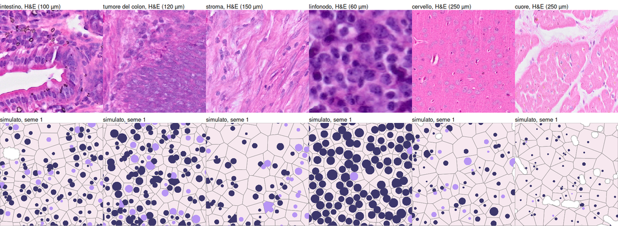

## Da dove vengono i numeri del riassunto

| frase del riassunto | fonte (file, riga) | valore letto |
| --- | --- | --- |
| raggio mediano 4,86 µm con la scala giusta e con quella 10 volte più grande | tests/final2/test_S1.5.log, riga E10d | 4.862 vs 4.857 µm |
| le altre 81 passano | tests/final2/test_S1.5.log, RESULT | 81/83 (FAIL: E10, E10b) |
| metadati esatti in tutti e 5 i dataset | tests/final2/test_S1.5.log, riga S1 | 5 |
| 600 simulazioni senza errori | S1.5_panel_units.csv, n_error | 600/600 |
| rifatte con lo stesso seme danno file identici | S1.5_G3_repro.csv; S1.5_G3_recheck.csv md5 = md5_panel | 6/6; 600/600 |
| tutti i 630 guasti rilevati | S1.5_G4_faults_v2.csv, status_expected = ERROR | 630/630 |
| rilevati tutti i guasti costruiti dal revisore | S1.5_review_faults_after.csv, detected_any | 282/282 |
| 18 delle 19 modifiche sabotate del revisore | S1.5_review_mutants_after.csv, id R01-R19 | 18/19; non rilevato: R18 |
| stessi esiti dei controlli nelle 600 simulazioni | S1.5_G3_recheck.csv statuses = S1.5_panel_units.csv statuses | 600/600 |
| linfonodo: 5 minuti e 10 secondi, 8,5 GB | S1.5_verdicts.csv P-8 A4 | 310.1 s; 8.50 GB |
| altri tessuti da 18 secondi a poco più di 2 minuti | S1.5_verdicts.csv P-8 tempo | 18.1-128.8 s |
| area mediana del nucleo dentro la variabilità in sei tessuti; 13, 31, 64 µm² | S1.5_verdicts.csv P-1 | 6/6; 13.20, 31.09, 64.13 |
| sei tessuti su sei contro quattro | S1.5_size_rule.csv | preserve_area 6, none 4 |
| densità contate a mano diverse da quelle del modello | BIO_REFERENCES B-043…B-048; S1.4_calibration.csv (cellpose_rgb), R3b_refs.csv (A4, A6) | manuale / modello: A1 12419 / 10591; A2 8924 / 7723; A3 3100 / 4279; A4 28096 / 27897; A5 1185 / 1040; A6 988 / 1062 |
| frazione del nucleo giusta in quattro tessuti | S1.5_verdicts.csv P-2 | 4/6 |
| intestino 0,18 contro 0,22-0,23 | S1.5_verdicts.csv P-2 A1 | 0.183 [0.2165, 0.2309] |
| tumore del colon 0,306 contro almeno 0,309 | S1.5_verdicts.csv P-2 A2 | 0.306 ± 0.0009; limite 0.3094 |
| con i territori delle cellule vere torna (0,32) | S1.5_posthoc_units.csv realgen A2 median_nc | 0.321 |
| 3,6 % quasi senza citoplasma contro al massimo 2,9 % | S1.5_verdicts.csv P-4 A2 | 0.0358; massimo reale 0.0287 |
| tumore del colon 62 su 100 contro 22-57 | S1.5_verdicts.csv P-5 A2 | 0.620 [0.217, 0.567] |
| linfonodo 83 contro 35-75 | S1.5_verdicts.csv P-5 A4 | 0.832 [0.35, 0.75] |
| intestino e cervello tornano; stroma e cuore al limite | S1.5_verdicts.csv P-5 | A1 confermata, A3 indeterminata, A5 confermata, A6 indeterminata |
| con i centri veri dentro in cinque tessuti, al limite nel linfonodo | S1.5_posthoc_windows.csv realgen (media dei semi) | A1 0.496, A2 0.498, A3 0.181, A4 0.739, A5 0.065, A6 0.049 |
| variabilità delle aree più bassa di un quarto fino a quasi la metà, in cinque tessuti | S1.5_verdicts.csv P-6 | A1 -0.416, A2 -0.415, A3 -0.435, A4 -0.424, A5 -0.260 |
| nel cuore torna, ma è fragile | S1.5_verdicts.csv P-6 A6; review/review_recalc.json SENS-P6-A6 | -0.056 [-0.1000, -0.0112]; indeterminata, ±2ES [-0.10542, -0.02173] (escludendo rapporto > 1: [-0.10586, -0.02065]) |
| a 1 micron per pixel la scala giusta solo nel linfonodo; nel cuore sbaglia di 4 volte | S1.5_CP1_verdicts.csv pipeline, 1 µm/px | A1 indeterminata; A2 rifiuto (>= 3 ROI su 5); A3 rifiuto (>= 3 ROI su 5); A4 confermata; A5 rifiuto (>= 3 ROI su 5); A6 smentita; cuore 3.98 |
| 23 casi su 120 un numero sbagliato senza avvisare | S1.5_CP1_scale.csv pipeline, non rifiutati con abs(rapporto − 1) > 0.2 | 23/120 |
| un controllo aggiunto dopo li riduce a 8 | S1.5_CP1_scale_est_b.csv, stessa regola | 8/120 |